# ISA 401: Business Intelligence & Data Visualization

# Describe a Chart in Grammar

**Task.** In 4 minutes, describe this chart (from Wednesday) in the grammar of graphics: its data (what is one row?), aesthetics, geometries, facets, and any other layers you can see.

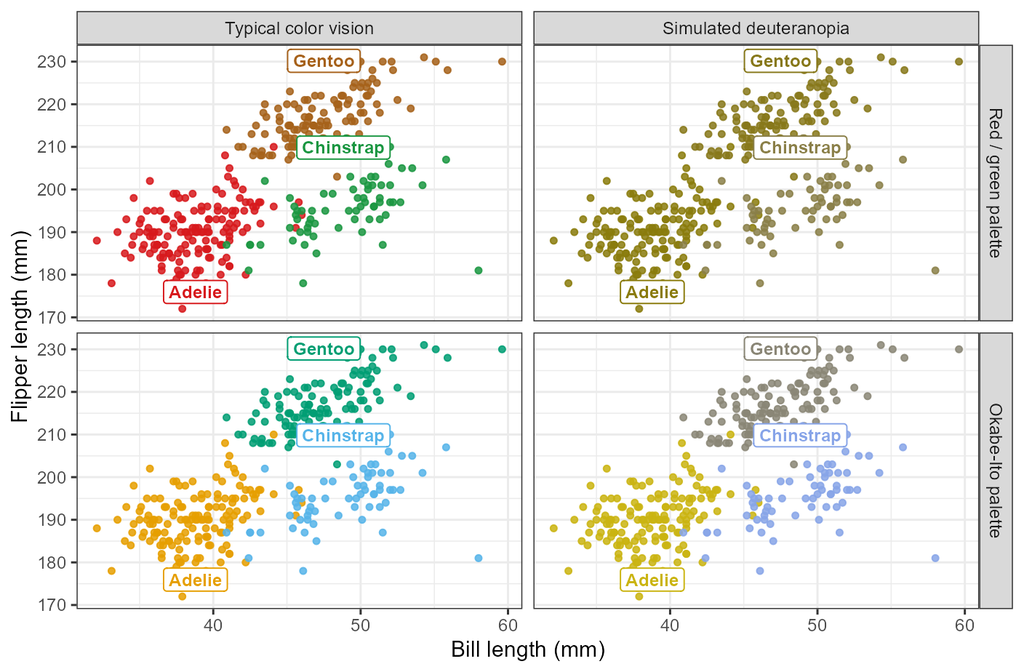

Start typing. Your answer is checked when you pause.

<details class="answer-gate">
<summary>Show the answer</summary>


<table>
<thead><tr><th>Layer</th><th>In this chart</th></tr></thead>
<tbody>
<tr><td>Data</td><td>One row per penguin per panel: 342 penguins, repeated in 4 panels (1,368 rows). A second table of species means places the labels.</td></tr>
<tr><td>Aesthetics</td><td>x = bill length, y = flipper length, color = the species color for that panel, label = species (for the labels).</td></tr>
<tr><td>Geometries</td><td>Points (one per row) and labels (one per species).</td></tr>
<tr><td>Facets</td><td>A grid: rows = palette, columns = vision.</td></tr>
<tr><td>Other layers</td><td>Scales: the colors are used as stored. Labels: axis titles. Theme: theme_bw(). Coordinates: Cartesian (the default).</td></tr>
</tbody>
</table>

<pre class='rcode' style='font-size:54%;'>ggplot2::ggplot(data = cvd,                # data  ggplot2::aes(x = bill_len,               # aesthetics    y = flipper_len)) +  ggplot2::geom_point(                     # geometry: points    ggplot2::aes(color = col), size = 1.1, alpha = 0.85) +  ggplot2::geom_label(data = cvd_lab,      # geometry: labels    ggplot2::aes(label = species, color = col),    size = 2.8, fontface = "bold", linewidth = 0.3) +  ggplot2::scale_color_identity() +        # scales  ggplot2::facet_grid(palette ~ vision) +  # facets  ggplot2::labs(x = "Bill length (mm)",    # labels    y = "Flipper length (mm)") +  ggplot2::theme_bw(base_size = 10)        # theme</pre>

</details>

.panel[Discussion

- Edit me to include any notes/discussion

# Refine a Draft

What would you change? The code appears on Step 1.

```
ggplot2::ggplot(data = home26,  ggplot2::aes(x = opponent, y = attendance)) +  ggplot2::geom_col()
```

```
ggplot2::ggplot(data = home26,      # data  ggplot2::aes(                     # aesthetics    x = forcats::fct_reorder(game, date),    y = attendance, fill = family_weekend)) +  ggplot2::geom_col(width = 0.6) +  # geometry  ggplot2::scale_fill_manual(       # scales    values = c("grey65", "#C3142D"), guide = "none")
```

```
ggplot2::ggplot(data = home26,      # data  ggplot2::aes(                     # aesthetics    x = forcats::fct_reorder(game, date),    y = attendance, fill = family_weekend)) +  ggplot2::geom_col(width = 0.6) +  # geometry  ggplot2::geom_text(               # direct labels    ggplot2::aes(label = scales::comma(attendance)),    vjust = -0.4, size = 3.4) +  ggplot2::scale_fill_manual(       # scales    values = c("grey65", "#C3142D"), guide = "none") +  ggplot2::scale_y_continuous(labels = scales::comma,    limits = c(0, 20000))
```

```
ggplot2::ggplot(data = home26,      # data  ggplot2::aes(                     # aesthetics    x = forcats::fct_reorder(game, date),    y = attendance, fill = family_weekend)) +  ggplot2::geom_col(width = 0.6) +  # geometry  ggplot2::geom_text(               # direct labels    ggplot2::aes(label = scales::comma(attendance)),    vjust = -0.4, size = 3.4) +  ggplot2::scale_fill_manual(       # scales    values = c("grey65", "#C3142D"), guide = "none") +  ggplot2::scale_y_continuous(labels = scales::comma,    limits = c(0, 20000)) +  ggplot2::labs(                    # labels    title = paste("The Family Weekend game had the largest",                  "home crowd of 2026", sep = "\n"),    subtitle = "Home games through Oct 17, 2026",    x = NULL, y = "Attendance")
```

```
ggplot2::ggplot(data = home26,      # data  ggplot2::aes(                     # aesthetics    x = forcats::fct_reorder(game, date),    y = attendance, fill = family_weekend)) +  ggplot2::geom_col(width = 0.6) +  # geometry  ggplot2::geom_text(               # direct labels    ggplot2::aes(label = scales::comma(attendance)),    vjust = -0.4, size = 3.4) +  ggplot2::scale_fill_manual(       # scales    values = c("grey65", "#C3142D"), guide = "none") +  ggplot2::scale_y_continuous(labels = scales::comma,    limits = c(0, 20000)) +  ggplot2::labs(                    # labels    title = paste("The Family Weekend game had the largest",                  "home crowd of 2026", sep = "\n"),    subtitle = "Home games through Oct 17, 2026",    x = NULL, y = "Attendance") +  ggplot2::theme_minimal()          # theme
```

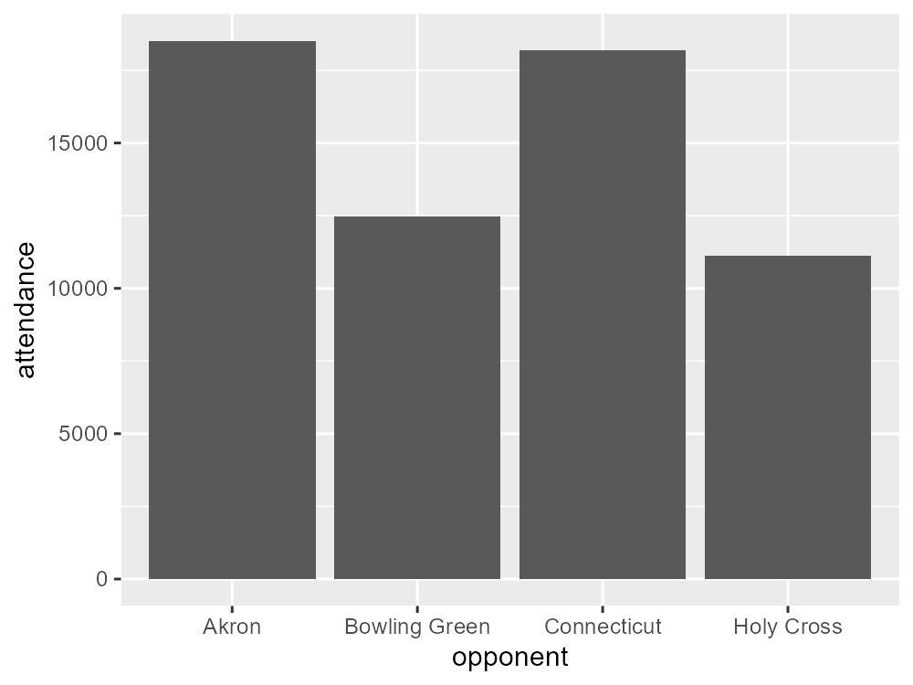

[figure not shown]

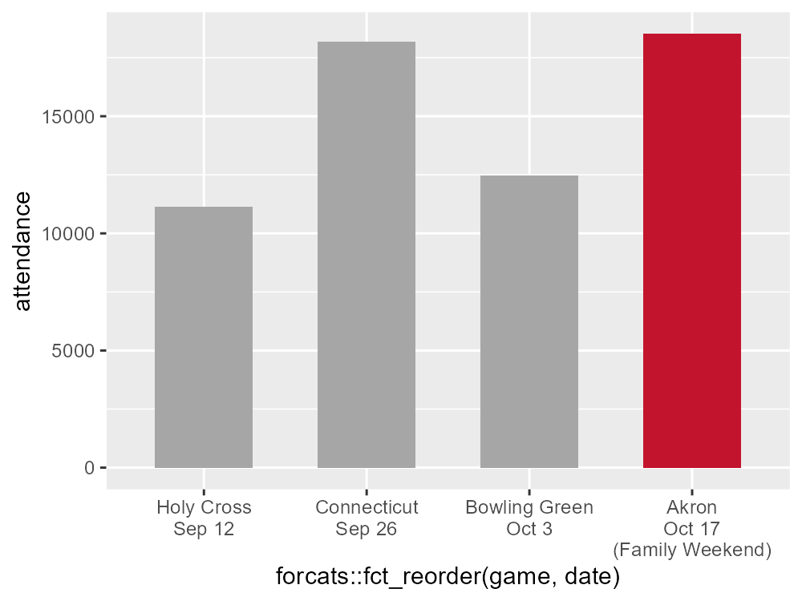

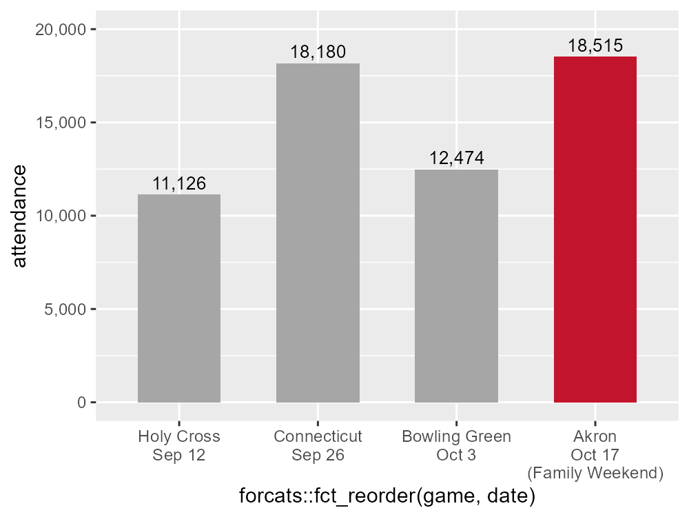

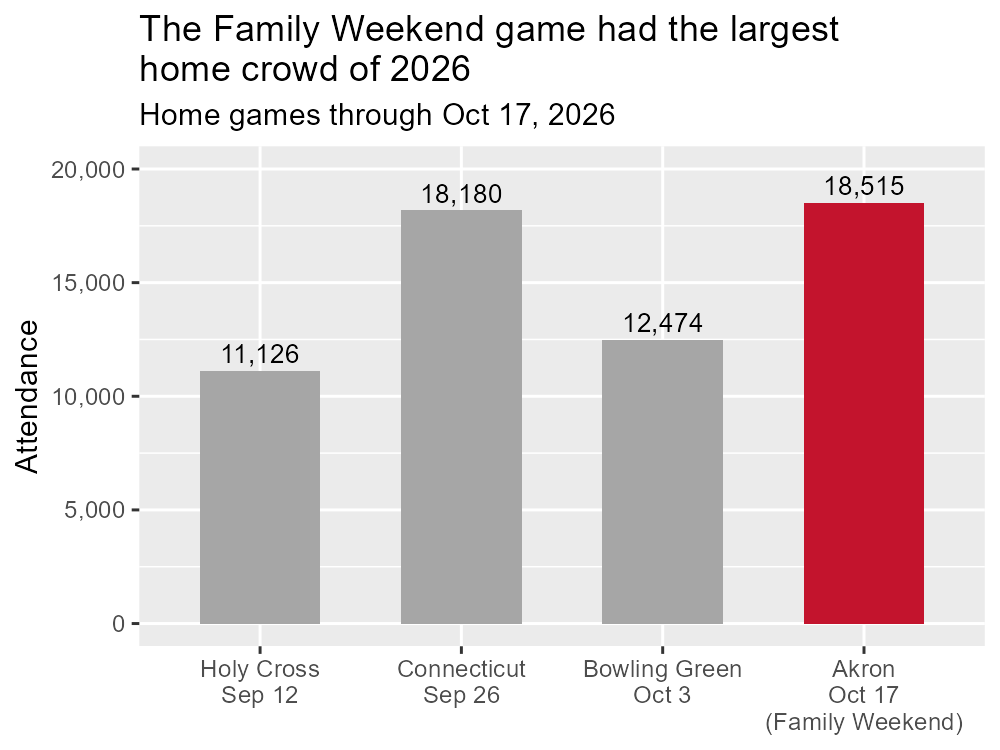

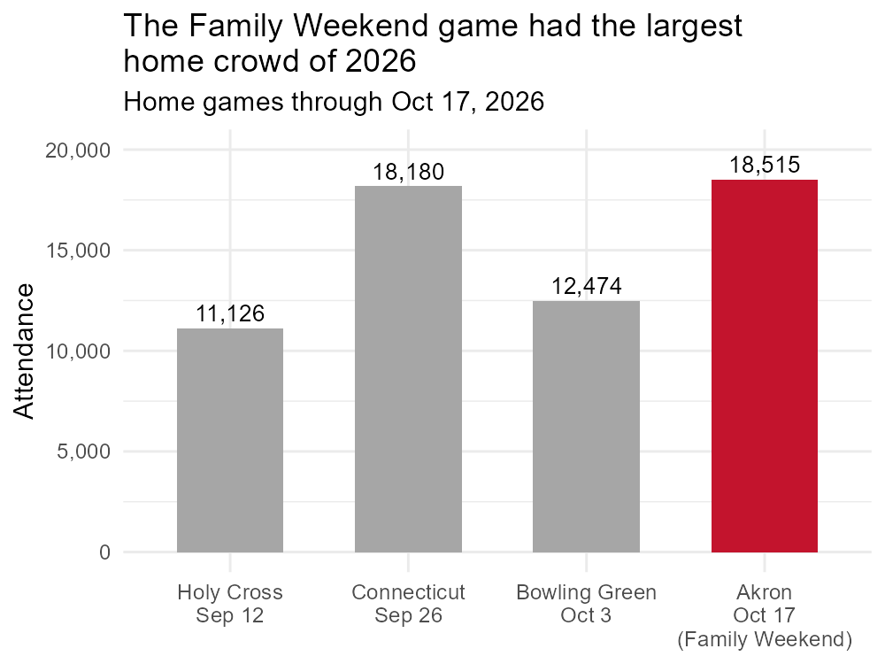

**A draft.** This is ggplot2's default chart of this season's home attendance. What would you change before showing it to someone?

**The draft's code: three lines.** The bars are in alphabetical order, the y-axis numbers have no commas, the axis titles are column names, and there is no title.

**Aesthetics and scales.** The games are in date order, and fill = family_weekend maps the Family Weekend game to its own color. scale_fill_manual() sets gray and Miami red and drops the legend.

**Direct labels.** geom_text() prints each attendance above its bar, and scale_y_continuous() adds commas to the axis.

**Labels.** The title states the finding, and the subtitle gives the scope: the four home games through Oct 17. The axis titles are no longer column names.

**Theme.** theme_minimal() removes the gray background. Each refinement was one layer.

0 / 5

Attendance: official box scores ([Holy Cross](https://miamiredhawks.com/sports/football/stats/2026/holy-cross/boxscore/20837), [Connecticut](https://miamiredhawks.com/sports/football/stats/2026/connecticut/boxscore/20839), [Bowling Green](https://miamiredhawks.com/sports/football/stats/2026/bowling-green/boxscore/20840), [Akron](https://miamiredhawks.com/sports/football/stats/2026/akron/boxscore/20842)). Family Weekend (Oct 16-18, 2026): [Miami University News](https://miamioh.edu/news/2026/10/family-weekend-puts-focus-on-miami-traditions-oct-16-18.html).

# Part 3: Game Day at Yager

# Game Day at Yager

How to play

**1.** You joined at the start of class. If you did not, scan your section's code now.

**2.** Each question appears on the screen. Answer on your phone.

**3.** A right answer earns points, and a faster right answer earns more. Every question is worth double points (up to 2,000).

**4.** Two questions ask you to type a short answer. They are scored by the ideas you include, not by speed.

**5.** 14 questions: four quarters and a two-minute drill.

Points count for nothing: no grade and no bonus. The screen shows only your first name and seat.

Join

Section A (8:30 AM)

[figure not shown]

isa401-game-day.vercel.app/?section=A

Section B (10:05 AM)

[figure not shown]

isa401-game-day.vercel.app/?section=B

Enter your **preferred first name** and **last initial**, then **tap your seat** (or **Joining remotely**).

**20 minutes.** The questions cover Wednesday and today: distortion, data-ink, data types, encodings, color, and the grammar of graphics.

# The Class Project

1 Question

A research question or business problem your team finds interesting.

→

2 Data

At least **3 real-world sources** and **2 methods**: web scraping, APIs, LLM extraction. Not Kaggle.

→

3 R pipeline

Acquire, clean, merge, and validate in **R**, in a **GitHub repository**.

→

4 Dashboard

**Tableau** (Storyboard) or **Power BI**, built on your merged data.

→

5 Presentations

A **technical video** (8 to 12 min) and an **in-class talk** (8 to 9 min).

Start now

**1.** Form a team of 3 (4 at most) on the [**Canvas Groups page**](https://miamioh.instructure.com/courses/258169/groups#tab-59773).  
**2.** One teammate opens the [**project template**](https://github.com/fmegahed/isa401_project_template), clicks **Use this template**, and adds the others as collaborators. Everyone clones the new repository.  
**3.** Suggested check-in, **Fri Oct 30** (not a deadline): your topic and planned sources.

Hand in by Fri Dec 4, 11:59 PM

**Team:** one link, your repository. Its README links the dashboard, the video, and each member.  
**Each of you:** add the project to your portfolio and update your skills.  
**Presentations**, FSB 2050: Section B Wed Dec 9, 10:15 AM; Section A Fri Dec 11, 8:00 AM.

Full guidelines, past projects, and Spring 2026 storyboards: the [Project page on Canvas](https://miamioh.instructure.com/courses/258169/assignments/3622330).

# Part 4: Exam 01 Review

# Exam 01 at a Glance

**Scores ranged from 42% to 100%.** Based on exams graded as of Oct 14, 2026.

Six questions showed a real AI answer. In five of them, the AI was wrong in a way you only catch by checking.

| Question | The AI answer | What checking shows |
| --- | --- | --- |
| Q1: What is one row? | Two models counted rows as penguins: Adelie had the most. | One row is one capture. Counting bands gives 220 penguins; Gentoo had the most. |
| Q3: One vector, one type | ChatGPT said the code prints 7. | Run it: it prints 0, because the vector is text. |
| Q4: Nested JSON | Both models' code looked for a buildings element. | `names(campus)` shows there is no buildings element. |
| Q6: Calling an API | One model filtered on `crash_date`; the other's code counts rows (2,400 in July), but each row is a person. | The column is `crashdate`. The 2,400 rows are people; there were 1,166 crashes. |
| Q11: Extracting structure from text | ChatGPT's ellmer code named no model. | With the class key, it does not run until the model is named. |
| Q10: dplyr | Gemma said the result has 12 rows. | Correct. This was the one AI answer that was right. |

Score range: [Canvas](https://miamioh.instructure.com/courses/258169) item analysis (instructor view), based on exams graded as of Oct 14, 2026. Questions and answers: the Exam 01 answer key (instructor view on [Canvas](https://miamioh.instructure.com/courses/258169)). Q6 counts: the [Cincinnati traffic crash API](https://data.cincinnati-oh.gov/resource/rvmt-pkmq.json), July 2026.

# The Three Lowest-Scoring Questions

Percent of possible points earned on each question: the three lowest of the 13.

Q1: What is one row?

61%

Worth 3 points.  
Two AI models counted rows as penguins. Was that right?

Q12: LLMs and private data

67%

Worth 1 point.  
How do you analyze a table with an LLM without sending it the rows?

Q11: Extracting structure from text

72%

Worth 2 points.  
Why does ChatGPT's ellmer code fail with the class key?

The next three slides go through each one.

Based on exams graded as of Oct 14, 2026. Percent = points earned on the question across graded exams ÷ points possible on it ([Canvas](https://miamioh.instructure.com/courses/258169) item analysis, instructor view).

# Q1: What Is One Row?

What the two AI models said

**Grok:** Adelie 152, Chinstrap 68, Gentoo 124. Adelie had the most.

**Second model** (OpenAI, via an ellmer API call) ran `table(d$species)` and agreed.

Five real rows of the file

| band | species | island | year | body_mass |
| --- | --- | --- | --- | --- |
| **60106** | Adelie | Dream | 2007 | 3950 |
| **60106** | Adelie | Dream | 2008 | 4000 |
| **60106** | Adelie | Dream | 2009 | 3800 |
| **60109** | Chinstrap | Dream | 2007 | 3350 |
| **60109** | Chinstrap | Dream | 2008 | 3500 |

Band **60106** is one penguin caught in three years; band **60109** is one penguin caught twice.

Count penguins, not rows

One row is **one capture** of a banded penguin. A penguin is one band.

```
penguins |> dplyr::distinct(species, band) |> dplyr::count(species)
```

```
# A tibble: 3 × 2
  species       n
  <chr>     <int>
1 Adelie       80
2 Chinstrap    45
3 Gentoo       95
```

**220 penguins** (344 rows). **Gentoo** had the most, not Adelie.

Both models counted the same rows, so their agreement did not check anything.

Data: [`data/penguin_captures.csv`](https://raw.githubusercontent.com/fmegahed/isa401/main/data/penguin_captures.csv) (the Exam 01 file). The counts on this slide are computed from it.

# Q12: Keep the Rows Away From the LLM

**In short.** In one sentence, describe the general approach that lets you analyze a table with an LLM without sending it the raw data.

Your data

The rows stay on your computer.

→schema only

The LLM

Sees column names and types, and writes a query (SQL or R code).

→the query

Your computer

Runs the query on the data locally and shows you the result.

**Half credit:** only the schema (column names and types) goes to the model, not the rows.

**Half credit:** the code the model writes runs locally, where the data stay.

Full credit needed both halves. Fewer than half of graded exams earned full credit; the most common partial score was half credit. Based on exams graded as of Oct 14, 2026.

# Q11: Name the Model

**The question.** ChatGPT's ellmer code does not run with the class key. Why not, and which one line fixes it?

As written

```
chat <- ellmer::chat_openai()
```

No model is named, so ellmer uses its default model. The class key only allows the class model, so a call that names no model is refused.

The fix

```
chat <- ellmer::chat_openai(model = "gpt-5.6-luna")
```

With the class model named, the code runs and returns the listing's fields: a mansion that sleeps 19, with 9 bedrooms.

**When code fails, look for a default you did not choose.** Here it was the model. If ChatGPT's code ran as written for you, there was no fault to find, and you received full credit.

# Below 80%? Come Talk to Me

Book a time

[**Automated Scheduler for Office Hours** (Calendly)](https://calendly.com/fmegahed)  
Mondays and Wednesdays, 12:45 to 3:00 PM, in FSB 2004 or on Zoom. Book at least 2 hours ahead.

What we will do

Go through your exam one question at a time, and make a plan for Exam 02 (Mon Nov 16).  
If none of the times work, email me and we will find another time.

**If your Exam 01 score is below 80%,** please book a meeting.

# Recap

# Summary of Main Points

By now, you should be able to do the following:

- **Apply** the grammar of graphics using ggplot2: every chart has data, aesthetics, and a geometry; facets, statistics, coordinates, scales, and a theme are added with <b>+</b> and have defaults.

- **Map** data types to visual encodings in code: a column inside aes() is mapped to a channel, a value outside aes() is set for every mark, and the color scale should match the data type (qualitative for nominal data, sequential or diverging for ordered values).

- **Refine** charts with labels, scales, and themes: a title that states the finding, axis labels with units, direct labels where they help, and a theme for the parts that do not show data.

- **Critique** and improve draft visualizations by changing one layer at a time, and check what one row is before you count or chart it.

# Before Next Class

**Wednesday, Oct 21: Lab: Tableau + Power BI.** We import data, build common charts with filters, and make a multi-view dashboard in both tools.

Suggested

Wickham, Çetinkaya-Rundel, and Grolemund, *R for Data Science* (2e): [**ch. 1, Data visualization**](https://r4ds.hadley.nz/data-visualize).

Healy, *Data Visualization: A Practical Introduction*: [**ch. 3, Make a Plot**](https://socviz.co/03-ggplot-basics.html).

Free online. A second explanation of mappings and geoms in ggplot2.

Skim if curious

Wickham, H. (2010). [**A Layered Grammar of Graphics**](https://doi.org/10.1198/jcgs.2009.07098). *Journal of Computational and Graphical Statistics*, 19(1), 3-28.

The paper behind ggplot2's layers.